# Práctica Final Machine Learning - Ejercicios 1, 2 y 3

Marina García Cervera (m.garciacervera@um.es)

Curso 24/25

## **1. Introducción**

El **análisis de regiones funcionales del genoma humano** es fundamental para comprender su organización y regulación. A partir de un conjunto amplio de características este trabajo explora cómo distintas **técnicas de aprendizaje automático** pueden ayudar a clasificar regiones genómicas como **UTRs**, **ncRNAs**, **pseudogenes** o **regiones codificantes**.

Se ha establecido un workflow que abarca desde la **limpieza y preprocesamiento de los datos**, pasando por la **reducción de dimensionalidad mediante Análisis de Componentes Principales (PCA)**, hasta la construcción y evaluación de **modelos de clasificación multiclase**. Entre los modelos entrenados destacan **Random Forest y SVM con kernel radial**.

Además de comparar el rendimiento de los modelos, se ha analizado la **importancia relativa de los predictores**, identificando las variables que más contribuyen a la diferenciación entre tipos de loci. Todo el análisis ha sido implementado en **R**, utilizando la cola del **clúster del máster** para gestionar el entrenamiento de los modelos de forma eficiente.

## **2. Objetivos**

El objetivo principal de la práctica es utilizar **técnicas de análisis de datos** para clasificar distintos tipos de regiones genómicas en el genoma humano, basándose en información de **expresión génica y características genómicas**.

Para alcanzar este objetivo, se deben cumplir los **siguientes subobjetivos**:

2.1. Explorar y limpiar los datos.

- Identificar balance de clases, valores nulos y correlaciones.

2.2. Reducir dimensionalidad con PCA.

- Determinar qué predictores son más informativos.

2.3. Construir y evaluar clasificadores.

- Entrenar Random Forest y SVM, optimizar hiperparámetros y seleccionar el mejor modelo.

2.4. Documentar y justificar resultados.

- Presentar análisis en R Markdown, con visualizaciones de calidad y modelos guardados en `.RDS`.

## **3. Metología y resultados**

## **3.1. Análisis descriptivo de los datos. Exploración y limpieza de los mismos.**

**3.1.1. Cargar y explorar el dataset.**

Cargar las librerías necesarias.

```r
library(caret)
```

```r
library(ggplot2)
```

Definir la ruta del archivo.

```r
set.seed(123)  # Asegurar reproducibilidad
data_path <- "/home/alumno08/ML/PracticaMLDataset2425.rds"
mydata <- readRDS(data_path)
```

Se hace una inspección inicial.

```r
dim(mydata)     # Número de filas y columnas
```

```
## [1] 179968     42
```

```r
str(mydata)     # Estructura del dataset
```

```
## 'data.frame':    179968 obs. of  42 variables:
##  $ polyA_signal                : Factor w/ 2 levels "0","1": 2 2 2 2 1 2 2 2 2 2 ...
##  $ meanPd                      : num  186 178 189 191 182 ...
##  $ meanEE                      : num  0.973 0.963 0.968 0.945 0.972 ...
##  $ mean_phastCons7way          : num  0.315 0.693 0.692 0.13 0.423 ...
##  $ aphilicity                  : num  0.677 0.679 0.726 0.603 0.655 ...
##  $ basestacking                : num  -7.33 -7.44 -6.78 -7.89 -7.75 ...
##  $ bdnatwist                   : num  35.7 36 35.9 35.5 36 ...
##  $ bendability                 : num  -0.03027 -0.00512 -0.03967 -0.01489 -0.02072 ...
##  $ bendingstiffness            : num  54.2 55.9 45.9 66.8 62 ...
##  $ cpgislands                  : num  0.0714 0.1317 0.0682 0.1296 0.1116 ...
##  $ cpnpgcpgislands             : num  0.144 0.211 0.106 0.242 0.227 ...
##  $ cpnpgislands                : num  0.246 0.205 0.118 0.346 0.361 ...
##  $ dnadenaturation             : num  79.1 80 74.9 84.6 82.4 ...
##  $ duplexstabilitydisruptenergy: num  1.78 1.83 1.71 1.97 1.89 ...
```

[output cut: 28 more lines]

```r
summary(mydata) # Estadísticas básicas
```

```
##  polyA_signal     meanPd             meanEE       mean_phastCons7way
##  0:152900     Min.   :  0.6822   Min.   :0.2739   Min.   :0.0004792
##  1: 27068     1st Qu.:  9.7442   1st Qu.:0.9947   1st Qu.:0.3674794
##               Median : 19.8437   Median :0.9990   Median :0.8461977
##               Mean   : 47.2727   Mean   :0.9890   Mean   :0.6701516
##               3rd Qu.: 47.2414   3rd Qu.:0.9996   3rd Qu.:0.9464432
##               Max.   :199.9933   Max.   :1.0000   Max.   :1.0000000
##
##    aphilicity      basestacking       bdnatwist      bendability
##  Min.   :0.3885   Min.   :-10.502   Min.   :34.14   Min.   :-0.141531
##  1st Qu.:0.5927   1st Qu.: -8.382   1st Qu.:35.49   1st Qu.:-0.026883
##  Median :0.6354   Median : -7.992   Median :35.71   Median :-0.015520
##  Mean   :0.6324   Mean   : -8.022   Mean   :35.72   Mean   :-0.016655
##  3rd Qu.:0.6746   3rd Qu.: -7.624   3rd Qu.:35.93   3rd Qu.:-0.005477
##  Max.   :0.8388   Max.   : -5.747   Max.   :38.15   Max.   : 0.061892
##
##  bendingstiffness   cpgislands     cpnpgcpgislands   cpnpgislands
##  Min.   : 33.00   Min.   :0.0000   Min.   :0.0000   Min.   :0.0000
##  1st Qu.: 58.21   1st Qu.:0.1043   1st Qu.:0.1912   1st Qu.:0.2764
##  Median : 64.68   Median :0.1606   Median :0.2750   Median :0.3765
##  Mean   : 65.30   Mean   :0.1920   Mean   :0.3039   Mean   :0.3801
##  3rd Qu.: 71.69   3rd Qu.:0.2449   3rd Qu.:0.3889   3rd Qu.:0.4773
##  Max.   :104.80   Max.   :1.1064   Max.   :1.2926   Max.   :1.2500
##
##  dnadenaturation  duplexstabilitydisruptenergy duplexstabilityfreeenergy
##  Min.   : 67.43   Min.   :1.460                Min.   :-2.353
##  1st Qu.: 81.03   1st Qu.:1.843                1st Qu.:-1.739
##  Median : 84.28   Median :1.950                Median :-1.625
##  Mean   : 84.65   Mean   :1.986                Mean   :-1.641
##  3rd Qu.: 87.88   3rd Qu.:2.093                3rd Qu.:-1.526
##  Max.   :104.64   Max.   :3.088                Max.   :-1.136
##
##  nucleosomeposition propellortwist    proteindeformation proteindnatwist
##  Min.   :-20.1639   Min.   :-15.942   Min.   :3.366      Min.   :33.57
##  1st Qu.: -0.4197   1st Qu.:-13.233   1st Qu.:4.542      1st Qu.:34.09
##  Median :  3.3900   Median :-12.618   Median :4.810      Median :34.16
##  Mean   :  3.3815   Mean   :-12.598   Mean   :4.851      Mean   :34.16
##  3rd Qu.:  7.2014   3rd Qu.:-11.971   3rd Qu.:5.118      3rd Qu.:34.23
##  Max.   : 21.4474   Max.   : -9.515   Max.   :6.964      Max.   :34.71
##
```

[output cut: 33 more lines]

```
##  Min.   :0.00000   Min.   :0.00000   Min.   :0.00000   Min.   :0.00000
##  1st Qu.:0.05469   1st Qu.:0.03268   1st Qu.:0.03922   1st Qu.:0.05882
##  Median :0.07080   Median :0.04587   Median :0.05882   Median :0.07412
##  Mean   :0.07416   Mean   :0.04647   Mean   :0.06481   Mean   :0.07534
##  3rd Qu.:0.09091   3rd Qu.:0.05882   3rd Qu.:0.08377   3rd Qu.:0.09091
##  Max.   :0.28846   Max.   :0.32653   Max.   :0.30159   Max.   :0.27660
##
##        CT                CG                  class
##  Min.   :0.00000   Min.   :0.000000   5-UTR     : 21641
##  1st Qu.:0.05263   1st Qu.:0.009434   ICE       :129868
##  Median :0.06842   Median :0.020833   lncRNA    :  3694
##  Mean   :0.06949   Mean   :0.030363   ncRNA     :  3796
##  3rd Qu.:0.08475   3rd Qu.:0.040678   pseudoGene:  2133
##  Max.   :0.26984   Max.   :0.270833   UTR       : 17592
##                                       NA's      :  1244
```

**3.1.2. Distribución de la variable `class`.**

```r
# Calcular distribución de clases
class_counts <- table(mydata$class)

# Calcular porcentaje de cada clase
class_percent <- prop.table(class_counts) * 100

# Mostrar resultados con dos decimales
round(class_percent, 2)
```

```
##
##      5-UTR        ICE     lncRNA      ncRNA pseudoGene        UTR
##      12.11      72.66       2.07       2.12       1.19       9.84
```

La variable de clase `class` presenta un notable desbalance, con una predominancia clara de la clase **ICE** (72.66%) frente a otras categorías como **lncRNA**, **ncRNA** y **pseudogenes**, que tienen una representación muy reducida. Esta disparidad puede afectar negativamente el rendimiento de los clasificadores, que tienden a favorecer la clase mayoritaria. Para mitigar este efecto, se aplicaron estrategias de balanceo como el downsampling antes del entrenamiento.

**3.1.3. Valores nulos.**

Para detectar cuántos valores nulos hay en cada variable:

```r
# Contar valores nulos por columna
missing_values <- colSums(is.na(mydata))

# Imprimir el conteo completo
print(missing_values)
```

```
##                 polyA_signal                       meanPd
##                            0                            0
##                       meanEE           mean_phastCons7way
##                            0                            0
##                   aphilicity                 basestacking
##                            0                            0
##                    bdnatwist                  bendability
##                            0                            0
##             bendingstiffness                   cpgislands
##                            0                            0
##              cpnpgcpgislands                 cpnpgislands
##                            0                            0
##              dnadenaturation duplexstabilitydisruptenergy
##                            0                            0
##    duplexstabilityfreeenergy           nucleosomeposition
##                            0                            0
##               propellortwist           proteindeformation
##                            0                            0
##              proteindnatwist                         zdna
##                            0                          525
##               RepeatsOverlap                            A
##                            0                            0
##                            T                            G
##                            0                            0
##                            C                           AA
##                            0                            0
##                           TT                           GG
##                            0                            0
##                           CC                           AT
##                            0                            0
##                           AG                           AC
##                            0                            0
##                           TA                           TG
##                            0                            0
##                           TC                           GA
##                            0                            0
##                           GT                           GC
##                            0                            0
##                           CA                           CT
##                            0                            0
##                           CG                        class
##                            0                         1244
```

Se detectan valores nulos en dos variables: `zdna`, con 525 valores faltantes, y `class`, con 1244 observaciones incompletas. Dado que `class` representa la variable objetivo, las filas sin esta información no son útiles para el entrenamiento y se eliminan. En cuanto a `zdna`, al tratarse de una variable numérica predictora, se opta por una imputación más sofisticada mediante el método de los k vecinos más cercanos (kNN), que considera la similitud entre observaciones para estimar los valores perdidos de forma más realista que una simple imputación con la mediana.

```r
library(VIM)
# Primero, eliminar filas con NAs en 'class'
mydata <- mydata[!is.na(mydata$class), ]

# Después, imputar los valores NA en 'zdna' usando kNN con 5 vecinos cercanos
mydata_imputed <- kNN(mydata, variable = "zdna", k = 5)

# Actualizar únicamente la columna 'zdna' con los valores imputados
mydata$zdna <- mydata_imputed$zdna
```

Verificación final de los NAs eliminados en ambos casos:

```r
na_finales <- colSums(is.na(mydata))
print(na_finales[na_finales > 0]) # Debería imprimir un vector vacío si no quedan NAs
```

```
## named numeric(0)
```

**3.1.4. Correlaciones entre predictores.**

Calcular la **matriz de correlaciones** entre predictores numéricos con `cor()`.

```r
# Seleccionar solo variables numéricas (excluir 'class')
num_vars <- mydata[, sapply(mydata, is.numeric)]

# Calcular matriz de correlación
cor_matrix <- cor(num_vars, use = "pairwise.complete.obs")

# Visualizar primeras correlaciones
print(cor_matrix[1:5, 1:5])  # Mostrar un fragmento
```

```
##                        meanPd     meanEE mean_phastCons7way aphilicity
## meanPd              1.0000000 -0.6401563         -0.5354373 -0.1811059
## meanEE             -0.6401563  1.0000000          0.3399816  0.2034439
## mean_phastCons7way -0.5354373  0.3399816          1.0000000  0.2380897
## aphilicity         -0.1811059  0.2034439          0.2380897  1.0000000
## basestacking       -0.1106585  0.1865533          0.1609640  0.8682791
##                    basestacking
## meanPd               -0.1106585
## meanEE                0.1865533
## mean_phastCons7way    0.1609640
## aphilicity            0.8682791
## basestacking          1.0000000
```

El análisis de correlación entre predictores numéricos revela relaciones significativas entre varias variables. En particular, `aphilicity` y `basestacking` presentan una alta correlación positiva (0.868), lo que sugiere redundancia entre ambas. También se observan correlaciones negativas moderadas entre `meanEE` y `meanPd` (-0.64), y entre `mean_phastCons7way` y `meanPd` (-0.53), que podrían reflejar patrones biológicos opuestos en los datos.

Para prevenir problemas de multicolinealidad en los modelos predictivos y simplificar la estructura del dataset, se aplicó la función `findCorrelation()` del paquete `caret`, utilizando un umbral de 0.9, con el fin de eliminar únicamente aquellas variables que presentan correlaciones excesivas y redundantes.

```r
# Identificar variables con correlación mayor a 0.9
high_corr <- findCorrelation(cor_matrix, cutoff = 0.9)

# Mostrar nombres de las variables con alta correlación
colnames(mydata[, high_corr])
```

```
##  [1] "cpnpgislands"                 "duplexstabilitydisruptenergy"
##  [3] "proteindnatwist"              "bendability"
##  [5] "dnadenaturation"              "aphilicity"
##  [7] "nucleosomeposition"           "duplexstabilityfreeenergy"
##  [9] "cpgislands"                   "bendingstiffness"
## [11] "RepeatsOverlap"               "G"
```

Se eliminan estas variables para mejorar la estabilidad del modelo.

```r
mydata <- mydata[, -high_corr]
```

```r
# Calcular nueva matriz de correlaciones sin las variables redundantes
cor_matrix_new <- cor(mydata[, sapply(mydata, is.numeric)], use = "pairwise.complete.obs")
```

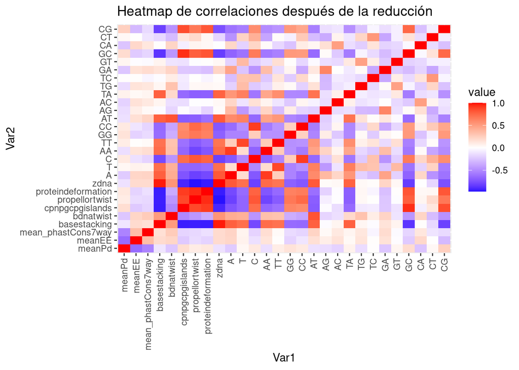

```r
library(reshape2)

# Convertir matriz de correlaciones a formato largo para ggplot2
cor_melted <- reshape2::melt(cor_matrix_new)

# Graficar el heatmap
ggplot(cor_melted, aes(Var1, Var2, fill = value)) +
  geom_tile() +
  scale_fill_gradient2(low = "blue", high = "red", mid = "white", midpoint = 0) +
  theme(axis.text.x = element_text(angle = 90, vjust = 0.5, hjust=1)) +
  labs(title = "Heatmap de correlaciones después de la reducción")
```

**Leyenda de colores:**

**Colores rojos:** correlaciones positivas altas (valores cercanos a +1).

**Colores azules:** correlaciones negativas altas (valores cercanos a -1).

**3.1.5. Asociaciones lineales con la variable `class`.**

Para examinar si las variables numéricas del dataset tienen una **asociación lineal significativa** con la variable categórica `class` se pueden utilizar dos enfoques:

- **ANOVA** (para comparar la media de las variables numéricas entre categorías de `class`).
- **Regresión logística multinomial** (para evaluar la influencia de las variables en la clasificación).

```r
library(car)  # Para ANOVA
library(nnet) # Para regresión logística multinomial

# Seleccionar variables numéricas
num_vars <- names(mydata)[sapply(mydata, is.numeric)]

# Aplicar ANOVA para evaluar la relación de cada variable numérica con la clase
anova_results <- lapply(num_vars, function(var) {
  model <- aov(mydata[[var]] ~ mydata$class)
  return(summary(model))
})

# Mostrar resultados de ANOVA de las primeras 5 variables
anova_results[1:5]
```

```
## [[1]]
##                  Df    Sum Sq  Mean Sq F value Pr(>F)
## mydata$class      5 391626415 78325283   54457 <2e-16 ***
## Residuals    178718 257049963     1438
## ---
## Signif. codes:  0 '***' 0.001 '**' 0.01 '*' 0.05 '.' 0.1 ' ' 1
##
## [[2]]
##                  Df Sum Sq Mean Sq F value Pr(>F)
## mydata$class      5  45.58   9.117   12344 <2e-16 ***
## Residuals    178718 132.00   0.001
## ---
## Signif. codes:  0 '***' 0.001 '**' 0.01 '*' 0.05 '.' 0.1 ' ' 1
##
## [[3]]
##                  Df Sum Sq Mean Sq F value Pr(>F)
## mydata$class      5   8964  1792.7   28900 <2e-16 ***
## Residuals    178718  11086     0.1
## ---
## Signif. codes:  0 '***' 0.001 '**' 0.01 '*' 0.05 '.' 0.1 ' ' 1
##
## [[4]]
##                  Df Sum Sq Mean Sq F value Pr(>F)
## mydata$class      5   7836  1567.2    6518 <2e-16 ***
## Residuals    178718  42971     0.2
## ---
## Signif. codes:  0 '***' 0.001 '**' 0.01 '*' 0.05 '.' 0.1 ' ' 1
##
## [[5]]
##                  Df Sum Sq Mean Sq F value Pr(>F)
## mydata$class      5   2209   441.9    4316 <2e-16 ***
## Residuals    178718  18299     0.1
## ---
## Signif. codes:  0 '***' 0.001 '**' 0.01 '*' 0.05 '.' 0.1 ' ' 1
```

```r
# Aplicar regresión logística multinomial
multi_logit <- multinom(class ~ ., data = mydata)
# Resumen del modelo
summary(multi_logit)
```

```
## Call:
## multinom(formula = class ~ ., data = mydata)
##
## Coefficients:
##            (Intercept) polyA_signal1       meanPd    meanEE mean_phastCons7way
## ICE          77.937040     0.3463892 -0.025322322 10.999980          3.7730120
## lncRNA       38.762992     1.4230097 -0.002046170  5.669215         -2.9060986
## ncRNA       -13.647930    -0.5768472 -0.005008543 -1.652630         -1.3164331
## pseudoGene    5.939958     1.0368144 -0.001137840  5.528891          0.4459137
## UTR          63.438783     2.5377491  0.012895295 15.994914         -1.0038104
##            basestacking bdnatwist cpnpgcpgislands propellortwist
## ICE            33.32382  9.893778       2.3474307       4.889016
## lncRNA         17.55557  5.167958      -4.0372748       1.133814
## ncRNA         -16.07155 -3.795370      -6.1664872       6.765700
## pseudoGene     14.61681 -1.877808      -0.3423949      -4.571291
## UTR            16.71325 15.613419       0.4687219       6.923856
##            proteindeformation       zdna          A         T          C
## ICE                 -8.943432  -32.69101 -25.146201 -34.25168 -7.1406404
## lncRNA              -2.804248  -27.85932  -5.649489 -10.34664 -5.0485360
## ncRNA                7.176209   11.78851 114.747728 117.86049 16.5425880
## pseudoGene          13.766351   14.59708 -58.579335 -58.68125 -0.9650734
## UTR                -28.724659 -104.77932  89.097227  79.43591  5.0390529
##                    AA          TT        GG         CC         AT        AG
## ICE         14.188252   5.1555013  9.708731  23.864792  23.785915  52.23273
## lncRNA      14.469454   5.9395875 13.884005  18.450521  44.862880  28.71764
## ncRNA       -6.655132   0.2226780  4.930367 -34.140596 -13.285452 -68.52053
## pseudoGene   7.872485  -0.3953082 16.988255  21.495180  53.015431  42.13185
## UTR        -18.995149 -14.5419037 -8.132237  -9.118453  -3.748084 -54.95652
##                    AC         TA         TG           TC       GA         GT
## ICE         105.69288 -52.761463  -22.96045    0.9891237 68.35558 168.422286
## lncRNA       47.09493 -27.667580  -25.30922  -17.7447925 48.70155 109.590541
## ncRNA      -130.99621 -18.813803  -79.37412 -102.9580915 27.47931   2.855423
## pseudoGene    7.19051 -16.665149   23.36928   -4.9998391 44.46994  43.970987
## UTR          47.60210  -6.811621 -120.12662  -77.2276040 54.17416 196.571766
##                   GC       CA        CT        CG
## ICE        137.64155 45.90312 131.09529 196.91180
## lncRNA      77.24154 45.61398 112.31940 106.11659
## ncRNA      -61.13970 35.49977  52.63962 -78.60442
## pseudoGene  21.95478 66.98042  91.02499  39.59467
## UTR        112.04951  5.39699  93.53854  95.46849
```

[output cut: 26 more lines]

```
##                   TA        TG        TC        GA        GT        GC
## ICE        0.2162902 0.2689571 0.3331758 0.3171341 0.3505228 0.4274362
## lncRNA     0.2656267 0.4365272 0.2784971 0.2206025 0.1945171 0.1724000
## ncRNA      0.2934021 0.4554141 0.3577420 0.3808557 0.3463832 0.1759955
## pseudoGene 0.2454359 0.4042588 0.1961179 0.2233680 0.2002333 0.1785298
## UTR        0.2858266 0.4514586 0.4779186 0.3794650 0.3631951 0.1628865
##                   CA        CT        CG
## ICE        0.2741682 0.2175447 0.1768700
## lncRNA     0.4585005 0.3053432 0.2614847
## ncRNA      0.4584548 0.3326761 0.2886115
## pseudoGene 0.4289607 0.2892220 0.2302451
## UTR        0.4804219 0.3505196 0.2736563
##
## Residual Deviance: 140869.5
## AIC: 141169.5
```

El **ANOVA** reveló **diferencias estadísticamente significativas** entre las clases para todas las variables numéricas del conjunto de datos (p < 2e-16), con valores F extremadamente altos, como el de `meanPd` (F = 54457), indicando una fuerte capacidad discriminativa. La **regresión logística multinomial** logró una convergencia efectiva tras 100 iteraciones, reduciendo la función de pérdida de 320230.42 a 70434.74 y alcanzando un AIC de 141169.5. Los coeficientes estimados pusieron de manifiesto el peso relativo de distintos predictores, como `meanEE`, `meanPd`, y proporciones de dinucleótidos y bases, que mostraron efectos diferenciadores relevantes.

**3.1.6. Distribución de variables clave.**

En este apartado se va a visualizar cómo se distribuyen los **valores de las principales variables del dataset** y detectar **posibles patrones** en los datos. Esto es útil para identificar **sesgos en la distribución de las variables**, detectar **valores atípicos** que puedan influir en los modelos y comparar la **variabilidad de cada variable** entre clases.

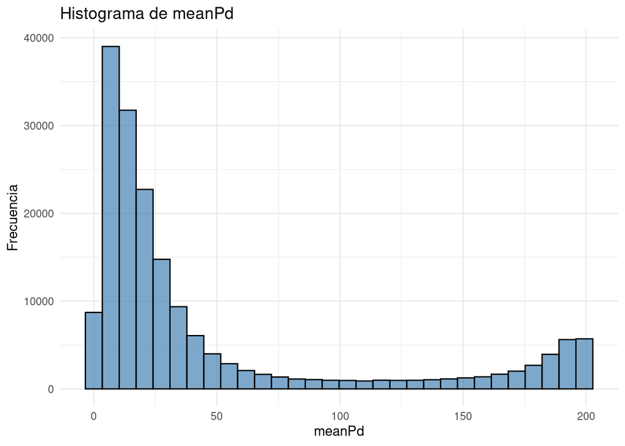

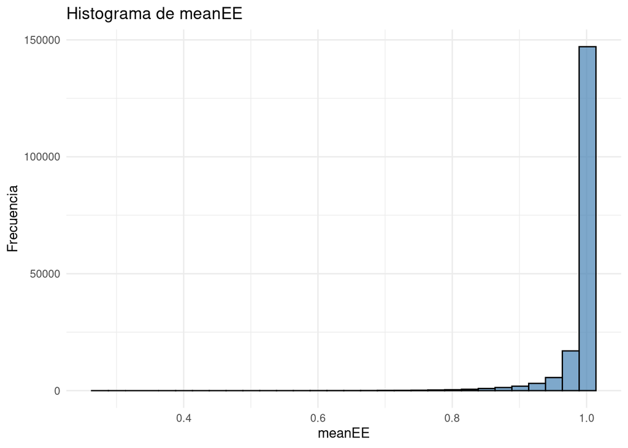

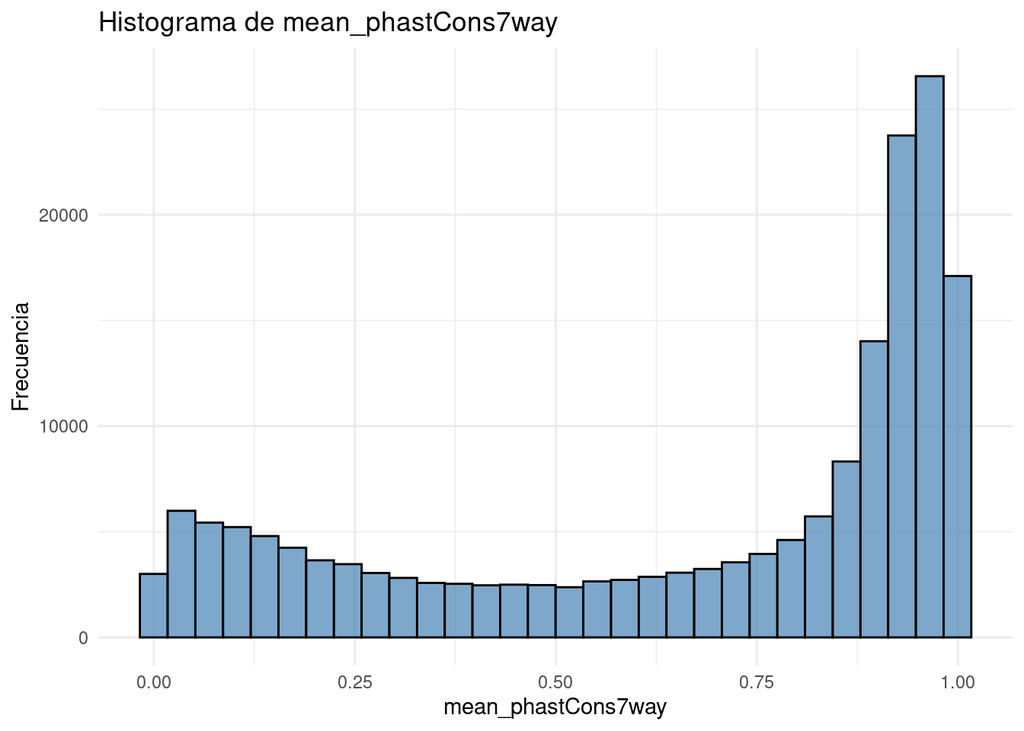

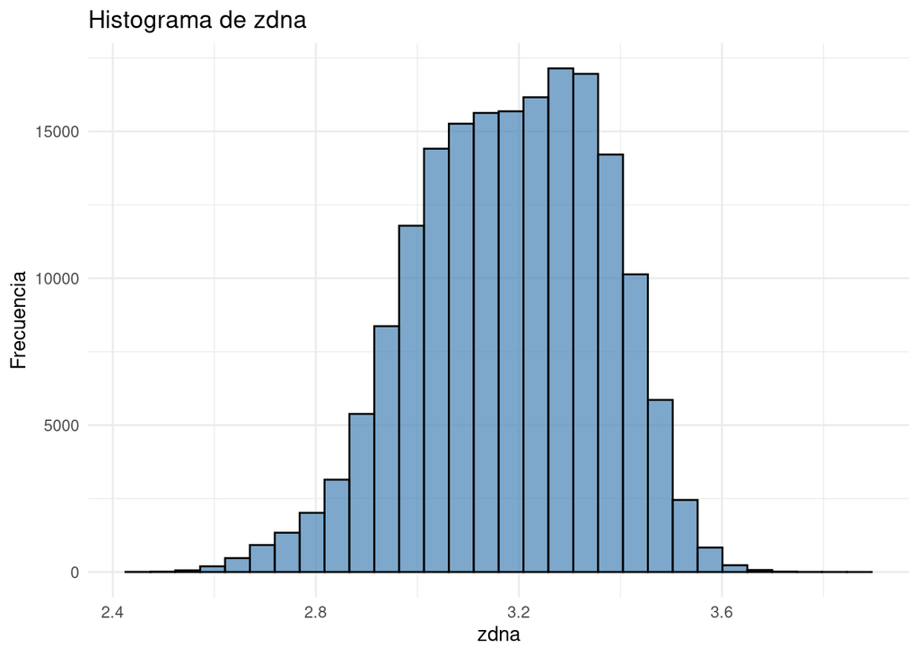

```r
# Variables clave a analizar (sin 'aphilicity')
vars_key <- c("meanPd", "meanEE", "mean_phastCons7way", "zdna")

# Verificar qué variables están en el dataframe
vars_exist <- vars_key[vars_key %in% colnames(mydata)]

# Generar histogramas para cada variable clave existente
for (var in vars_exist) {
  print(
    ggplot(mydata, aes(x = .data[[var]])) +
      geom_histogram(bins = 30, fill = "steelblue", color = "black", alpha = 0.7) +
      labs(title = paste("Histograma de", var), x = var, y = "Frecuencia") +
      theme_minimal()
  )
}
```

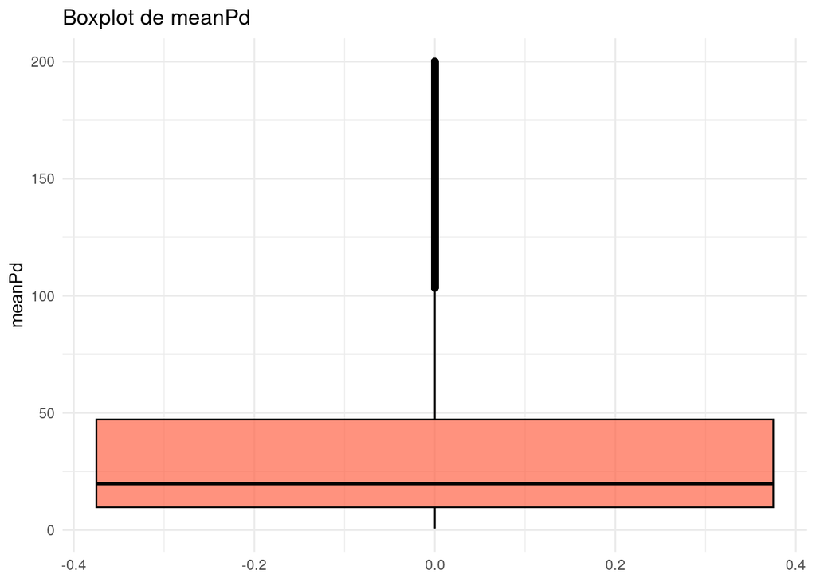

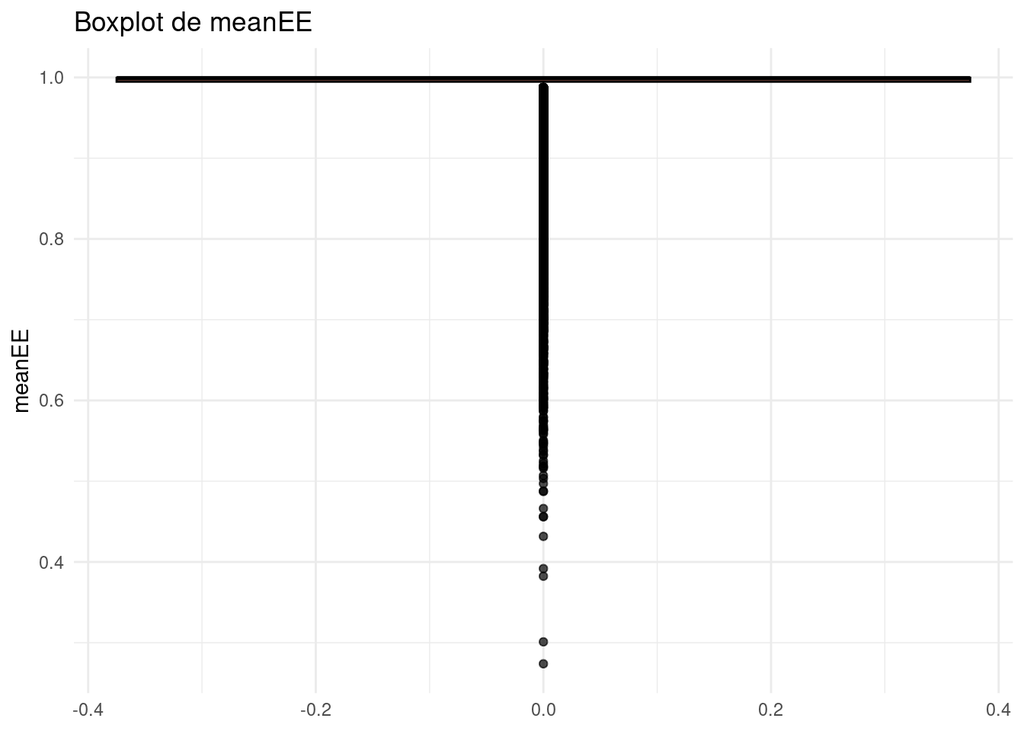

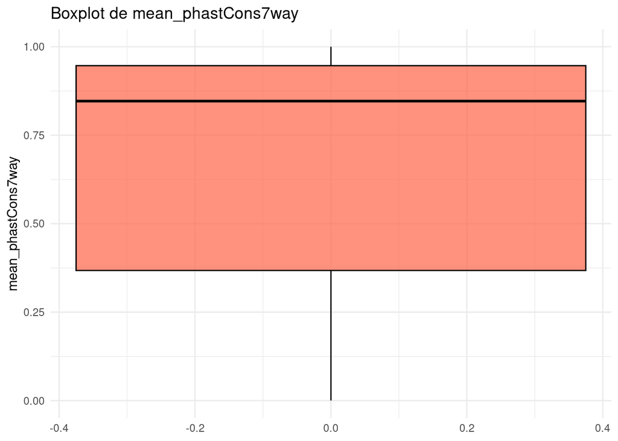

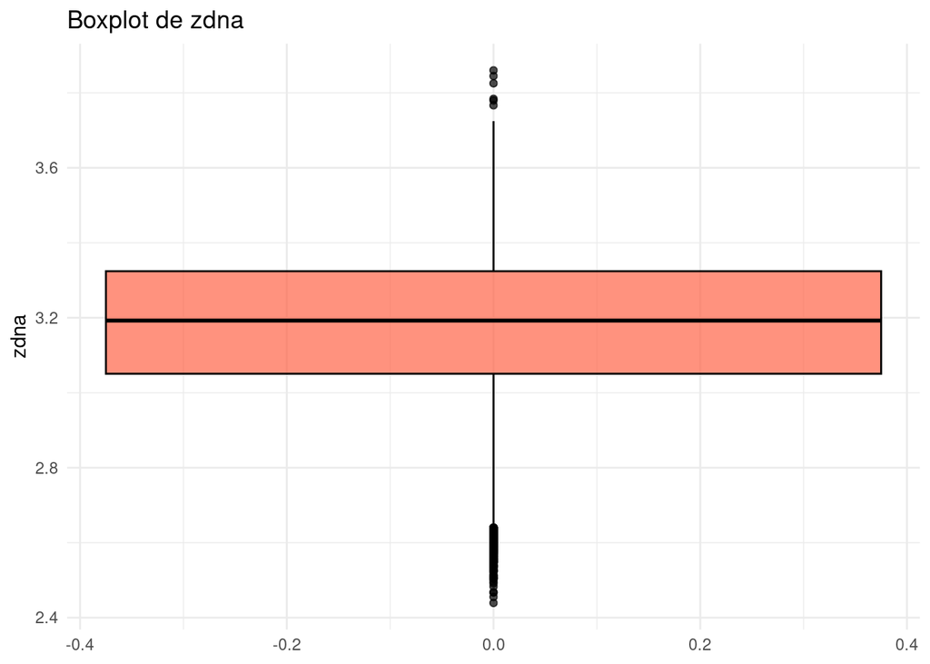

```r
# Generar boxplots para cada variable clave existente
for (var in vars_exist) {
  print(
    ggplot(mydata, aes(y = .data[[var]])) +
      geom_boxplot(fill = "tomato", color = "black", alpha = 0.7) +
      labs(title = paste("Boxplot de", var), y = var) +
      theme_minimal()
  )
}
```

- `meanPd`:

Sesgo a la derecha. Se aplica transformación logarítmica para reducir la cola larga.

```r
mydata$meanPd <- log1p(mydata$meanPd)
```

- `meanEE`:

Se convierte en variable categórica porque casi todos los valores están cerca de 1.

```r
mydata$meanEE <- ifelse(mydata$meanEE > 0.95, "Alto", "Bajo")
```

## **3.2. Análisis basado en PCA.**

```r
library(FactoMineR)
library(factoextra)
```

```r
library(ggplot2)
library(ggExtra)
library(dplyr)
# Seleccionar variables numéricas
datos_pca <- mydata[, sapply(mydata, is.numeric)]

# Estandarización
datos_pca <- scale(datos_pca)

# PCA sin gráficos automáticos
pca_res <- PCA(datos_pca, graph = FALSE)

# Ver resumen de la varianza explicada
pca_res$eig[1:5, ]  # PC1-PC5
```

```
##        eigenvalue percentage of variance cumulative percentage of variance
## comp 1  11.616808              43.025215                          43.02521
## comp 2   3.508591              12.994783                          56.02000
## comp 3   2.360171               8.741374                          64.76137
## comp 4   1.894355               7.016129                          71.77750
## comp 5   1.313548               4.864991                          76.64249
```

Se aplicó un **Análisis de Componentes Principales (PCA)** sobre las variables numéricas del dataset, previamente estandarizadas, con el objetivo de identificar patrones latentes y reducir la dimensionalidad de los datos. Los resultados mostraron que los dos primeros componentes principales explican conjuntamente un **56% de la varianza total (PC1: 43%, PC2: 13%)**, lo que respalda su utilización como plano principal para la visualización y análisis exploratorio.

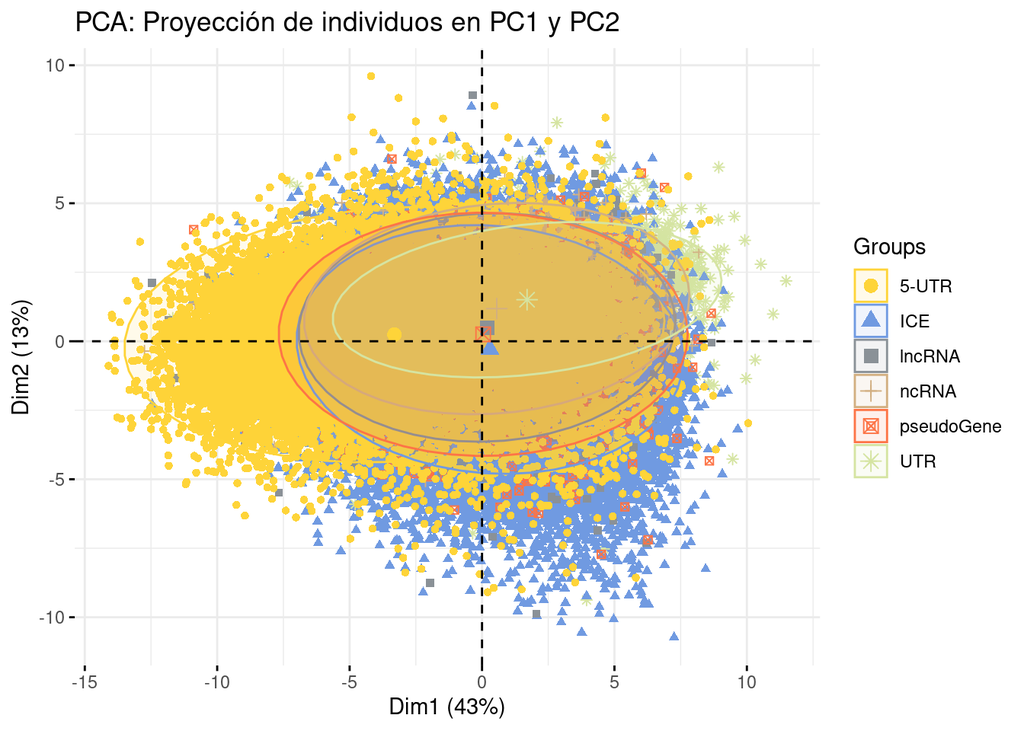

```r
# Gráfico general de individuos en PC1 y PC2
fviz_pca_ind(pca_res,
             geom = "point",
             habillage = mydata$class,
             addEllipses = TRUE,
             ellipse.level = 0.95,
             palette = "simpsons") +
  ggtitle("PCA: Proyección de individuos en PC1 y PC2")
```

```r
pca_df <- as.data.frame(pca_res$ind$coord)
pca_df$class <- mydata$class
```

```r
library(ggpubr)
library(ggExtra)
library(cowplot)
# Paleta de colores npg personalizada
npg_colors <- get_palette("npg", 6)
npg_palette <- setNames(npg_colors, c("5-UTR", "ICE", "lncRNA", "ncRNA", "pseudoGene", "UTR"))

# Función de gráfico PCA
grafico_pca <- function(df, titulo) {
  p <- ggplot(df, aes(x = Dim.1, y = Dim.2, color = class)) +
    geom_point(size = 0.6, alpha = 0.4) +
    scale_color_manual(values = npg_palette) +
    theme_minimal() +
    labs(x = "PC1", y = "PC2") +
    guides(color = guide_legend(override.aes = list(size = 3)))

  p_margin <- ggMarginal(p, type = "density", groupFill = TRUE, groupColour = TRUE)

  # Combinar título externo con el gráfico
  final_plot <- plot_grid(
    draw_label(titulo, fontface = 'bold', size = 14, hjust = 0.5),
    p_margin,
    ncol = 1,
    rel_heights = c(0.1, 1)
  )

  return(final_plot)
}
```

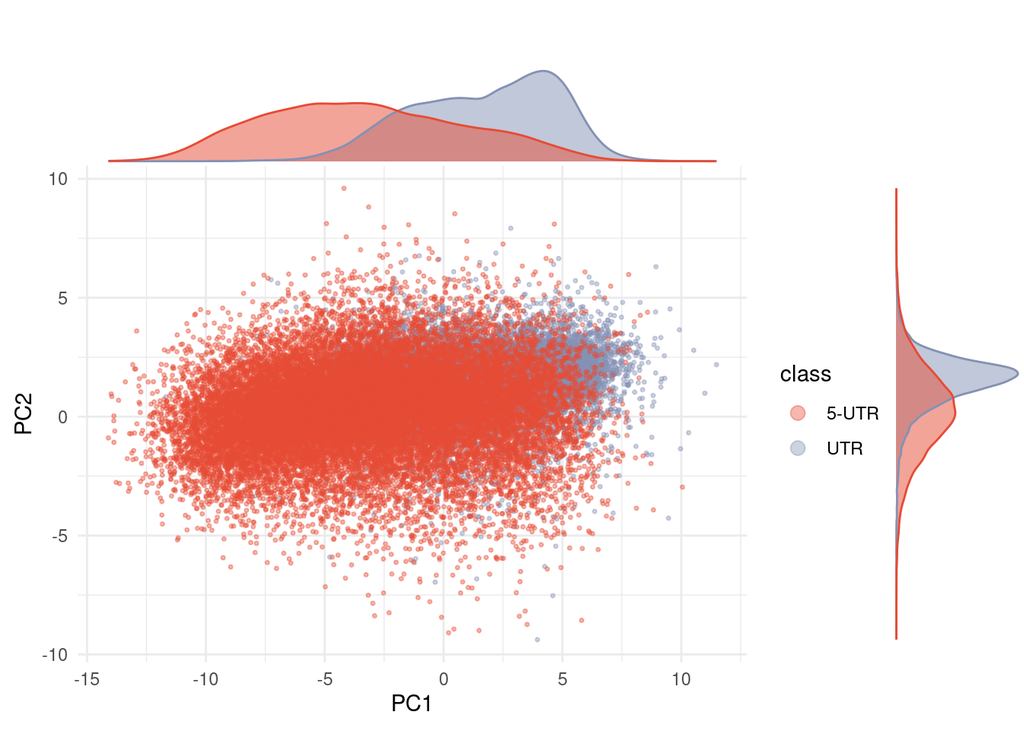

```r
grafico_pca(filter(pca_df, class %in% c("5-UTR", "UTR")), "PCA: UTR vs 5-UTR")
```

```r
cat('\n')
```

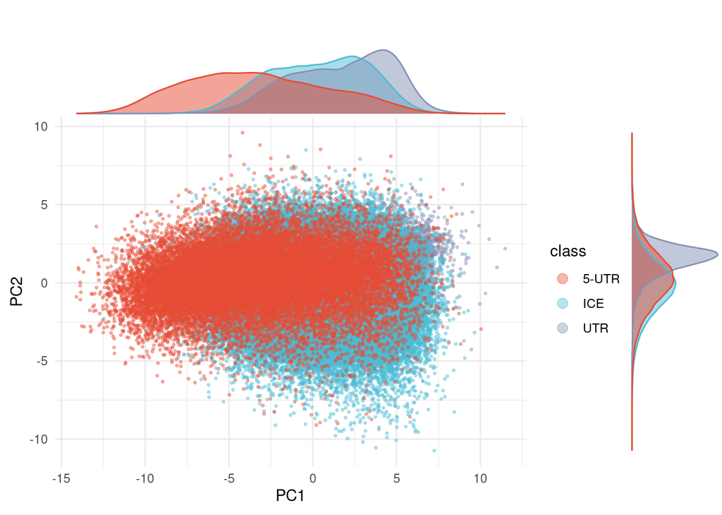

```r
grafico_pca(filter(pca_df, class %in% c("5-UTR", "UTR", "ICE")), "PCA: UTR vs 5-UTR vs ICE")
```

```r
cat('\n')
```

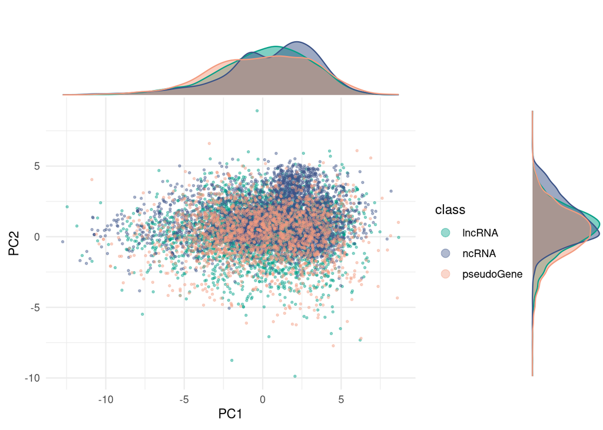

```r
grafico_pca(filter(pca_df, class %in% c("ncRNA", "lncRNA", "pseudoGene")), "PCA: ncRNA vs lncRNA vs pseudoGene")
```

```r
# Contribución de las variables (coordenadas en ejes)
pca_contrib <- as.data.frame(pca_res$var$coord)

# Top 5 de cada componente
top_PC1 <- rownames(pca_contrib[order(-abs(pca_contrib[, "Dim.1"])), ])[1:5]
top_PC2 <- rownames(pca_contrib[order(-abs(pca_contrib[, "Dim.2"])), ])[1:5]

cat("Variables más importantes en PC1:", paste(top_PC1, collapse = ", "), "\n")
```

```
## Variables más importantes en PC1: zdna, basestacking, propellortwist, cpnpgcpgislands, proteindeformation
```

```r
cat("Variables más importantes en PC2:", paste(top_PC2, collapse = ", "), "\n")
```

```
## Variables más importantes en PC2: AG, GA, T, CT, TC
```

Al analizar qué variables son **responsables de la variabilidad** capturada en los dos primeros componentes, se observa que PC1 está altamente influenciado por características estructurales como `zdna`, `basestacking`, `propellortwist`, `cpnpgcpgislands` y `proteindeformation`. Estas variables reflejan propiedades físicas del ADN que parecen relevantes para diferenciar regiones como `ICE`. Por su parte, PC2 está dominado por la composición en nucleótidos (`AG`, `GA`, `T`, `CT`, `TC`), lo que sugiere que captura diferencias relacionadas con el contenido secuencial de las regiones genómicas.

**3.2.1. Identificación de las regiones.**

A partir de la proyección de los datos en los dos primeros componentes principales (PC1 y PC2), se pueden identificar **diferencias claras en la distribución espacial de algunas clases**.

Por el contrario, las clases `lncRNA`, `ncRNA` y `pseudoGene` aparecen densamente solapadas en la región central del gráfico, sin patrones distinguibles en las proyecciones. Sus distribuciones marginales son prácticamente indistinguibles, lo que indica que su separación mediante PCA será más difícil. Aunque `ncRNA` muestra cierta desviación respecto a las otras dos, en general estas clases no forman grupos definidos en los primeros componentes, lo que anticipa una mayor complejidad en su clasificación.

**3.2.2. Variabilidad de los tres componentes principales.**

En este caso, los tres primeros componentes principales explican conjuntamente un **64,76% de la varianza total del dataset**, con las siguientes contribuciones individuales:

- PC1: 43,03%
- PC2: 12,99%
- PC3: 8,74%

Esta proporción indica que **más de la mitad de la información presente en las variables originales se conserva en el espacio tridimensional definido por los tres primeros componentes**, lo que justifica su uso para visualización, compresión de datos y posibles reducciones dimensionales en etapas posteriores del análisis.

**3.2.3. Predictores más importantes en los dos primeros componentes.**

```r
# Cargas (loadings) en PC1 y PC2
loadings <- pca_res$var$coord[, 1:2]

# Mostrar las 10 variables más importantes en PC1
head(loadings[order(abs(loadings[,1]), decreasing = TRUE), ])
```

```
##                         Dim.1        Dim.2
## zdna                0.9917254  0.039795698
## basestacking        0.9803565  0.076551965
## propellortwist     -0.9605674  0.014404917
## cpnpgcpgislands    -0.9388971 -0.064736771
## proteindeformation -0.9384332  0.009323383
## GC                 -0.8621265 -0.059346089
```

```r
# Mostrar las 10 variables más importantes en PC2
head(loadings[order(abs(loadings[,2]), decreasing = TRUE), ])
```

```
##          Dim.1      Dim.2
## AG  0.04349427 -0.7617490
## GA  0.26156747 -0.7169753
## T   0.69711350  0.6775645
## CT -0.22591405  0.6276604
## TC -0.03238183  0.5869040
## A   0.81953156 -0.5020474
```

Las variables que más contribuyen al componente principal PC1 fueron `zdna`, `basestacking`, `propellortwist`, `cpnpgcpgislands` y `proteindeformation`, todas ellas relacionadas con propiedades físicas del ADN. Por su parte, las principales contribuyentes al componente PC2 fueron `AG`, `GA`, `T`, `CT` y `TC`, que reflejan principalmente la composición en nucleótidos y dinucleótidos. Esta estructura sugiere que PC1 actúa como un eje estructural del ADN, mientras que PC2 representa diferencias en la secuencia.

## **3.3. Clasificadores para distinguir diferentes loci en el dataset.**

**3.3.1. Random Forest.**

**BLOQUE 1:** preprocesamiento de datos y guardado.

```r
library(caret)
library(dplyr)

# Paso 1: Eliminar NAs en class
mydata <- mydata[!is.na(mydata$class), ]

# Paso 2: Eliminar variables altamente correlacionadas
numeric_vars <- mydata[, sapply(mydata, is.numeric)]
cor_matrix <- cor(numeric_vars, use = "pairwise.complete.obs")
vars_alta_correlacion <- findCorrelation(cor_matrix, cutoff = 0.9, names = TRUE)
mydata <- mydata[, !colnames(mydata) %in% vars_alta_correlacion]

# Paso 3: Eliminar variables con varianza cero
nzv <- nearZeroVar(mydata)
if (length(nzv) > 0) {
  mydata <- mydata[, -nzv]
}

# Paso 4: Separar train/test
set.seed(123)
trainIndex <- createDataPartition(mydata$class, p = 0.8, list = FALSE)
train_data <- mydata[trainIndex, ]
test_data  <- mydata[-trainIndex, ]

# Paso 5: Downsampling para balancear ICE
ice_data <- train_data[train_data$class == "ICE", ]
size_5utr <- nrow(train_data[train_data$class == "5-UTR", ])
set.seed(123)
downsampled_ice <- ice_data[sample(1:nrow(ice_data), size = size_5utr), ]
train_data <- rbind(train_data[train_data$class != "ICE", ], downsampled_ice)

# Paso 6: Escalar numéricas
preProc <- preProcess(train_data[, sapply(train_data, is.numeric)], method = c("center", "scale"))
train_data[, sapply(train_data, is.numeric)] <- predict(preProc, train_data[, sapply(train_data, is.numeric)])
test_data[, sapply(test_data, is.numeric)]  <- predict(preProc, test_data[, sapply(test_data, is.numeric)])

# Guardar objetos para el siguiente paso
saveRDS(list(train_data = train_data,
             test_data = test_data,
             preProc = preProc), file = "datos_procesados_rf.rds")
```

**BLOQUE 2:** entrenamiento del modelo.

Archivo `entrenar_rf_bloque2.R`.

```r
library(caret)
library(ranger)
library(doParallel)

# Activar paralelización
print("Iniciando clúster paralelo...")
cl <- makeCluster(detectCores() - 1)
registerDoParallel(cl)

# Cargar datos
print("Leyendo datos procesados desde RDS...")
datos <- readRDS("/home/alumno08/ML/datos_procesados_rf.rds")
print("Datos leídos correctamente.")

train_data <- datos$train_data
print("Datos de entrenamiento cargados.")

# Definir grid de hiperparámetros
print("Definiendo grid de hiperparámetros...")
rf_grid <- expand.grid(
  mtry = c(4, 6, 8),
  splitrule = "gini",
  min.node.size = c(5, 10)
)
print("Grid definido.")

# Configurar control del entrenamiento
print("Configurando validación cruzada...")
ctrl <- trainControl(
  method = "cv",
  number = 10,
  allowParallel = TRUE
)
print("Control configurado.")

# Entrenar modelo
print("Iniciando entrenamiento del modelo Random Forest...")
set.seed(123)
rf_model <- train(
  class ~ .,
  data = train_data,
  method = "ranger",
  tuneGrid = rf_grid,
  trControl = ctrl,
  num.trees = 300,
  importance = "impurity"
)
print("Entrenamiento completado.")

# Guardar modelo y objetos
print("Guardando modelo y datos asociados en RDS...")
saveRDS(list(
  rf_model = rf_model,
  train_data = train_data,
  test_data = datos$test_data,
  preProc = datos$preProc,
  rf_grid = rf_grid,
  train_control = ctrl
), file = "/home/alumno08/ML/modelo_y_datos_completos_rf.rds")
print("Modelo guardado correctamente.")

# Finalizar paralelización
stopCluster(cl)
print("Clúster detenido. Script finalizado correctamente.")
```

Archivo `.sh` para mandarlo a entrenar a la cola del cluster.

```r
#!/bin/bash
#SBATCH --job-name=rf_entrenamiento
#SBATCH --partition=ledley-q
#SBATCH --nodes=1
#SBATCH --ntasks=1
#SBATCH --cpus-per-task=20
#SBATCH --mem=32G
#SBATCH --time=2-00:00:00
#SBATCH --output=rf_entrenamiento.log

# Ir al directorio de trabajo
cd /home/alumno08/ML

# Ejecutar el R Markdown y renderizar a HTML
Rscript entrenar_rf_bloque2.R
```

Extracto del archivo `.log`.

```r
(base) [alumno08@dayhoff ML]$ tail -f rf_entrenamiento.log
Loading required package: parallel
[1] "Iniciando clúster paralelo..."
[1] "Leyendo datos procesados desde RDS..."
[1] "Datos leídos correctamente."
[1] "Datos de entrenamiento cargados."
[1] "Definiendo grid de hiperparámetros..."
[1] "Grid definido."
[1] "Configurando validación cruzada..."
[1] "Control configurado."
[1] "Iniciando entrenamiento del modelo Random Forest..."
[1] "Entrenamiento completado."
[1] "Guardando modelo y datos asociados en RDS..."
[1] "Modelo guardado correctamente."
[1] "Clúster detenido. Script finalizado correctamente."
```

**BLOQUE 3:** evaluación del modelo.

```r
library(caret)

# Ruta del modelo entrenado
modelo_path <- "/home/alumno08/ML/modelo_y_datos_completos_rf.rds"

# Cargar el modelo y los datos
cat("Leyendo modelo y datos...\n")
```

```
## Leyendo modelo y datos...
```

```r
res <- readRDS(modelo_path)

rf_model <- res$rf_model
test_data <- res$test_data

# Generar predicciones
cat("Realizando predicciones sobre test_data...\n")
```

```
## Realizando predicciones sobre test_data...
```

```r
rf_preds <- predict(rf_model, test_data)

# Calcular matriz de confusión
cat("Calculando matriz de confusión...\n")
```

```
## Calculando matriz de confusión...
```

```r
rf_cm <- confusionMatrix(rf_preds, test_data$class)

# Mostrar métricas principales
cat("Accuracy:", rf_cm$overall["Accuracy"], "\n")
```

```
## Accuracy: 0.8649488
```

```r
cat("Kappa:", rf_cm$overall["Kappa"], "\n")
```

```
## Kappa: 0.7065245
```

```r
# Mostrar métricas por clase
cat("\n--- Métricas por clase ---\n")
```

```
##
## --- Métricas por clase ---
```

```r
print(rf_cm$byClass)
```

```
##                   Sensitivity Specificity Pos Pred Value Neg Pred Value
## Class: 5-UTR       0.80614603   0.9114089      0.5562819      0.9715304
## Class: ICE         0.92076387   0.8918006      0.9576726      0.8089136
## Class: lncRNA      0.06639566   0.9963433      0.2768362      0.9806270
## Class: ncRNA       0.44664032   0.9957980      0.6975309      0.9880871
## Class: pseudoGene  0.04225352   0.9994337      0.4736842      0.9885727
## Class: UTR         0.88260375   0.9785253      0.8177509      0.9870715
##                   Precision     Recall         F1 Prevalence Detection Rate
## Class: 5-UTR      0.5562819 0.80614603 0.65830189 0.12109003   0.0976162498
## Class: ICE        0.9576726 0.92076387 0.93885563 0.72668010   0.6691007778
## Class: lncRNA     0.2768362 0.06639566 0.10710383 0.02064798   0.0013709362
## Class: ncRNA      0.6975309 0.44664032 0.54457831 0.02123552   0.0094846399
## Class: pseudoGene 0.4736842 0.04225352 0.07758621 0.01191875   0.0005036092
## Class: UTR        0.8177509 0.88260375 0.84894053 0.09842762   0.0868725869
##                   Detection Prevalence Balanced Accuracy
## Class: 5-UTR               0.175479828         0.8587775
## Class: ICE                 0.698673829         0.9062822
## Class: lncRNA              0.004952157         0.5313695
## Class: ncRNA               0.013597448         0.7212191
## Class: pseudoGene          0.001063175         0.5208436
## Class: UTR                 0.106233563         0.9305645
```

```r
# Mostrar matriz de confusión
cat("\n--- Matriz de confusión ---\n")
```

```
##
## --- Matriz de confusión ---
```

```r
print(rf_cm$table)
```

```
##             Reference
## Prediction   5-UTR   ICE lncRNA ncRNA pseudoGene   UTR
##   5-UTR       3489  1757    359   271        144   252
##   ICE          574 23915     83    95        180   125
##   lncRNA        30    61     49     6         13    18
##   ncRNA         37    70     16   339          6    18
##   pseudoGene     0    18      2     0         18     0
##   UTR          198   152    229    48         65  3105
```

```r
# Guardar evaluación en un nuevo RDS
cat("Guardando resultados en evaluacion_rf.rds...\n")
```

```
## Guardando resultados en evaluacion_rf.rds...
```

```r
saveRDS(rf_cm, file = "/home/alumno08/ML/evaluacion_rf.rds")

cat("Evaluación finalizada correctamente.\n")
```

```
## Evaluación finalizada correctamente.
```

El modelo **Random Forest** fue entrenado utilizando una validación cruzada de **10 pliegues y optimización de hiperparámetros mediante una búsqueda en grid**. Tras evaluar el rendimiento sobre el conjunto de prueba, se obtuvo una exactitud global (`Accuracy`) del **86,5%** y un coeficiente `Kappa` de **0,71**, lo que indica una **buena concordancia entre las predicciones del modelo y las clases reales*, incluso considerando el desbalance de clases. Estos resultados sugieren que el modelo es capaz de capturar patrones relevantes en los datos y generaliza adecuadamente sobre ejemplos no vistos.

**3.3.2. SVM.**

**BLOQUE 1:** preprocesamiento.

El preprocesamiento aplicado para el modelo SVM fue **idéntico** al utilizado en el modelo Random Forest, con el objetivo de garantizar una **comparación justa entre ambos algoritmos**.

**BLOQUE 2:** entrenamiento del modelo.

Archivo `entrenar_svm_bloque2.R`.

```r
library(caret)
library(doParallel)

# Iniciar clúster paralelo
print("Iniciando clúster paralelo...")
cl <- makeCluster(detectCores() - 1)
registerDoParallel(cl)

# Cargar datos ya procesados
print("Cargando datos desde RDS...")
datos <- readRDS("/home/alumno08/ML/datos_procesados_rf.rds")
train_data <- datos$train_data

# Definir grid de hiperparámetros
print("Definiendo grid de SVM...")
svm_grid <- expand.grid(
  sigma = c(0.01, 0.05, 0.1),
  C = c(1, 10, 100)
)

# Configurar validación cruzada
print("Configurando validación cruzada...")
ctrl <- trainControl(
  method = "cv",
  number = 10,
  allowParallel = TRUE
)

# Entrenar el modelo SVM radial
print("Entrenando modelo SVM radial...")
set.seed(123)
svm_model <- train(
  class ~ .,
  data = train_data,
  method = "svmRadial",
  tuneGrid = svm_grid,
  trControl = ctrl
)

# Guardar modelo
print("Guardando modelo y datos...")
saveRDS(list(
  svm_model = svm_model,
  train_data = train_data,
  test_data = datos$test_data,
  preProc = datos$preProc,
  svm_grid = svm_grid,
  train_control = ctrl
), file = "/home/alumno08/ML/modelo_y_datos_completos_svm.rds")

stopCluster(cl)
print("Clúster detenido. Entrenamiento finalizado correctamente.")
```

Archivo `.sh` para mandarlo a entrenar a la cola del cluster.

```r
#!/bin/bash
#SBATCH --job-name=svm_entrenamiento
#SBATCH --partition=ledley-q
#SBATCH --nodes=1
#SBATCH --ntasks=1
#SBATCH --cpus-per-task=20
#SBATCH --mem=32G
#SBATCH --time=2-00:00:00
#SBATCH --output=svm_entrenamiento.log

cd /home/alumno08/ML
Rscript entrenar_svm_bloque2.R
```

Extracto del archivo `.log`.

```r
(base) [alumno08@dayhoff ML]$ tail -f svm_entrenamiento.log
Loading required package: foreach
Loading required package: iterators
Loading required package: parallel
[1] "Iniciando clúster paralelo..."
[1] "Cargando datos desde RDS..."
[1] "Definiendo grid de SVM..."
[1] "Configurando validación cruzada..."
[1] "Entrenando modelo SVM radial..."
[1] "Guardando modelo y datos..."
[1] "Clúster detenido. Entrenamiento finalizado correctamente."
```

**BLOQUE 3:** evaluación del modelo.

```r
library(caret)

cat("Cargando modelo SVM desde RDS...\n")
```

```
## Cargando modelo SVM desde RDS...
```

```r
res <- readRDS("/home/alumno08/ML/modelo_y_datos_completos_svm.rds")

svm_model <- res$svm_model
test_data <- res$test_data

cat("Generando predicciones sobre test_data...\n")
```

```
## Generando predicciones sobre test_data...
```

```r
svm_preds <- predict(svm_model, test_data)

cat("Calculando matriz de confusión...\n")
```

```
## Calculando matriz de confusión...
```

```r
svm_cm <- confusionMatrix(svm_preds, test_data$class)

# Mostrar métricas generales
cat("Accuracy:", svm_cm$overall["Accuracy"], "\n")
```

```
## Accuracy: 0.8767836
```

```r
cat("Kappa:", svm_cm$overall["Kappa"], "\n")
```

```
## Kappa: 0.7274455
```

```r
# Mostrar métricas por clase
cat("\n--- Métrica por clase ---\n")
```

```
##
## --- Métrica por clase ---
```

```r
print(svm_cm$byClass)
```

```
##                   Sensitivity Specificity Pos Pred Value Neg Pred Value
## Class: 5-UTR      0.797365989   0.9259566      0.5973689      0.9707325
## Class: ICE        0.937589035   0.8870918      0.9566686      0.8424225
## Class: lncRNA     0.044715447   0.9971146      0.2462687      0.9802011
## Class: ncRNA      0.480895916   0.9932253      0.6063123      0.9887877
## Class: pseudoGene 0.002347418   0.9998867      0.2000000      0.9881076
## Class: UTR        0.891415577   0.9803563      0.8320509      0.9880524
##                   Precision      Recall          F1 Prevalence Detection Rate
## Class: 5-UTR      0.5973689 0.797365989 0.683028204 0.12109003   9.655307e-02
## Class: ICE        0.9566686 0.937589035 0.947032745 0.72668010   6.813273e-01
## Class: lncRNA     0.2462687 0.044715447 0.075688073 0.02064798   9.232835e-04
## Class: ncRNA      0.6063123 0.480895916 0.536370316 0.02123552   1.021208e-02
## Class: pseudoGene 0.2000000 0.002347418 0.004640371 0.01191875   2.797829e-05
## Class: UTR        0.8320509 0.891415577 0.860710855 0.09842762   8.773991e-02
##                   Detection Prevalence Balanced Accuracy
## Class: 5-UTR              0.1616305747         0.8616613
## Class: ICE                0.7121873426         0.9123404
## Class: lncRNA             0.0037490907         0.5209150
## Class: ncRNA              0.0168429299         0.7370606
## Class: pseudoGene         0.0001398914         0.5011171
## Class: UTR                0.1054501707         0.9358859
```

```r
# Mostrar matriz de confusión
cat("\n--- Matriz de confusión ---\n")
```

```
##
## --- Matriz de confusión ---
```

```r
print(svm_cm$table)
```

```
##             Reference
## Prediction   5-UTR   ICE lncRNA ncRNA pseudoGene   UTR
##   5-UTR       3451  1338    373   256        137   222
##   ICE          592 24352     84    86        207   134
##   lncRNA        18    67     33     4          9     3
##   ncRNA         64   126     19   365          5    23
##   pseudoGene     0     4      0     0          1     0
##   UTR          203    86    229    48         67  3136
```

```r
# Guardar resultado completo
saveRDS(svm_cm, file = "/home/alumno08/ML/evaluacion_svm.rds")
cat("Resultados guardados en evaluacion_svm.rds\n")
```

```
## Resultados guardados en evaluacion_svm.rds
```

El modelo **SVM con kernel radial** fue entrenado empleando una validación cruzada de **10 pliegues y una búsqueda en grid de hiperparámetros**, optimizando los valores de `sigma` y `C`. Al evaluar su rendimiento sobre el conjunto de prueba, se obtuvo una exactitud global (`Accuracy`) del **87,7%** y un coeficiente `Kappa` de **0,73**, lo que refleja una buena concordancia entre las predicciones y las clases verdaderas, incluso en presencia de un claro desbalance de clases. Estos resultados confirman que el modelo logra una discriminación efectiva entre las distintas categorías, aunque con limitaciones interpretativas en cuanto a la importancia individual de los predictores.

**3.3.3. Comparación de las métricas por modelo.**

```r
# Cargar evaluaciones guardadas
rf_cm <- readRDS("/home/alumno08/ML/evaluacion_rf.rds")
svm_cm <- readRDS("/home/alumno08/ML/evaluacion_svm.rds")
```

```r
library(dplyr)
library(tibble)
library(tidyr)
# Convertir a dataframes
rf_metrics <- as.data.frame(rf_cm$byClass) %>%
  rownames_to_column("Class") %>%
  mutate(Model = "Random Forest")

svm_metrics <- as.data.frame(svm_cm$byClass) %>%
  rownames_to_column("Class") %>%
  mutate(Model = "SVM radial")

# Unir los datos
metrics_comparadas <- bind_rows(rf_metrics, svm_metrics)

# Mantener solo las columnas más relevantes
metrics_comparadas <- metrics_comparadas %>%
  select(Class, Model, F1, `Balanced Accuracy`)
```

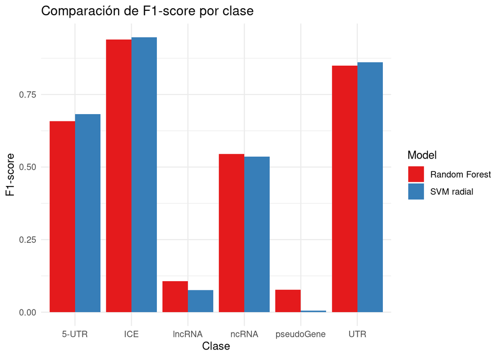

```r
library(ggplot2)

# Reordenar nombres de clase para mayor legibilidad
metrics_comparadas$Class <- gsub("Class: ", "", metrics_comparadas$Class)

# F1-score
ggplot(metrics_comparadas, aes(x = Class, y = F1, fill = Model)) +
  geom_col(position = "dodge") +
  labs(title = "Comparación de F1-score por clase",
       y = "F1-score", x = "Clase") +
  theme_minimal() +
  scale_fill_brewer(palette = "Set1")
```

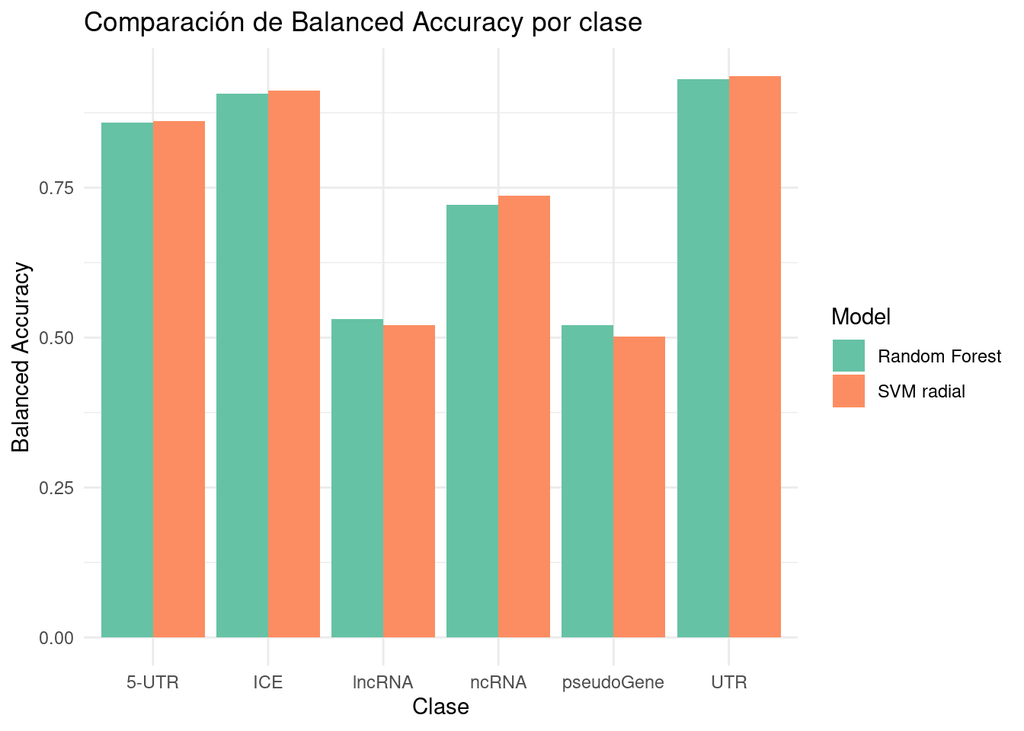

```r
# Balanced Accuracy
ggplot(metrics_comparadas, aes(x = Class, y = `Balanced Accuracy`, fill = Model)) +
  geom_col(position = "dodge") +
  labs(title = "Comparación de Balanced Accuracy por clase",
       y = "Balanced Accuracy", x = "Clase") +
  theme_minimal() +
  scale_fill_brewer(palette = "Set2")
```

La comparación de métricas por clase entre **Random Forest** y **SVM radial** revela un **rendimiento muy similar** en términos generales, aunque con diferencias específicas por clase. En la métrica `F1-score`, ambas técnicas obtienen valores muy altos en las clases más representadas del dataset, como `ICE` y `UTR`, donde **SVM** presenta una ligera ventaja. En cambio, **Random Forest** muestra un desempeño ligeramente mejor en clases minoritarias como `lncRNA`, `ncRNA` y especialmente `pseudoGene`, donde el **SVM** tiende a ofrecer `F1-scores` cercanos a cero.

Una tendencia similar se observa en la `Balanced Accuracy`, donde ambos modelos superan el **0.85** en las clases `ICE` y `UTR`, pero **Random Forest** obtiene mejores resultados para `lncRNA` y `pseudoGene`, dos clases con menor representación. Esto sugiere que, aunque ambos modelos generalizan bien en clases frecuentes, **Random Forest** es más robusto frente al desbalance de clases, capturando mejor los patrones de clases menos representadas.

**3.3.4. Optimización de hiperparámetros utilizados.**

En el modelo **Random Forest**, se empleó una estrategia de búsqueda en rejilla (`grid search`) utilizando `expand.grid()` para definir manualmente la parrilla de hiperparámetros. Esta búsqueda se integró dentro de un proceso de validación cruzada estratificada de 10 pliegues (`trainControl(method = "cv", number = 10)`), lo cual permitió comparar distintas combinaciones evaluando su rendimiento medio. Entre los hiperparámetros considerados se encuentra `mtry`, que representa el número de predictores aleatorios en cada división del árbol, evaluado con los valores 4, 6 y 8. Esta selección se justificó eligiendo valores en torno a la raíz cuadrada del número de predictores (≈6) para equilibrar diversidad y robustez. También se incluyó `min.node.size`, con valores 5 y 10, para evitar nodos hoja excesivamente pequeños que podrían causar sobreajuste. El criterio de división (`splitrule`) se fijó como `"gini"` por ser el valor predeterminado en `ranger` y por su eficiencia computacional. Finalmente, se entrenaron 300 árboles (`num.trees = 300`) buscando estabilidad en las predicciones sin incurrir en altos costes computacionales.

En cuanto al modelo **SVM con kernel radial**, se siguió una estrategia paralela basada también en `grid search`, combinando valores de hiperparámetros evaluados mediante validación cruzada de 10 pliegues. El entrenamiento se realizó con el método `"svmRadial"` del paquete `caret`, que utiliza internamente `kernlab`. Se evaluaron diferentes valores del parámetro de penalización `C` (1, 10, 100), que regula el equilibrio entre el ajuste del modelo y la generalización: valores bajos permiten más errores a favor de márgenes amplios, mientras que valores altos intentan clasificar todo correctamente aun con márgenes reducidos. El parámetro `sigma`, asociado al kernel radial (RBF), se evaluó con valores 0.01, 0.05 y 0.1, cubriendo desde kernels de influencia muy localizada (sigma pequeña) hasta kernels más suaves, permitiendo así adaptar el modelo a distintos patrones en los datos.

```r
rf_model <- readRDS("/home/alumno08/ML/modelo_y_datos_completos_rf.rds")$rf_model
rf_model$bestTune
```

```
##   mtry splitrule min.node.size
## 1    4      gini             5
```

```r
svm_model <- readRDS("/home/alumno08/ML/modelo_y_datos_completos_svm.rds")$svm_model
svm_model$bestTune
```

```
##   sigma   C
## 3  0.01 100
```

**3.3.5. Medidas de rendimiento y estrategia de remuestreo.**

Para evaluar y comparar los modelos entrenados se han utilizado tanto **métricas globales** como **métricas específicas por clase**, con el objetivo de proporcionar una evaluación exhaustiva del rendimiento en un problema multiclase y con desbalance. Entre las métricas globales se incluyen el `Accuracy`, que representa la proporción total de aciertos sobre el conjunto de prueba, y el coeficiente `Kappa`, que ajusta la precisión teniendo en cuenta el acuerdo esperado por azar. Las métricas por clase, obtenidas con `confusionMatrix()` del paquete `caret`, abarcan la `Sensitivity` (o Recall), que mide la capacidad del modelo para detectar los positivos reales de cada clase; la `Specificity`, que indica su capacidad para reconocer los negativos; la `Precision`, que muestra la proporción de verdaderos positivos sobre el total de predicciones positivas; el `F1-score`, que combina Precision y Recall de forma armónica; la `Balanced Accuracy`, que promedia Sensitivity y Specificity para evitar sesgos hacia clases mayoritarias; y otras medidas como el `Detection Rate` y la `Prevalence`, que aportan información sobre la frecuencia de cada clase y su reconocimiento por el modelo. En cuanto a la estrategia de remuestreo, se aplicó validación cruzada estratificada de 10 pliegues (`method = "cv"`, `number = 10`) tanto en el modelo de **Random Forest** como en el de **SVM radial**, garantizando que la proporción de clases se mantuviera estable en cada pliegue, lo cual es crucial en este contexto por la desproporción entre clases.

**3.3.6. Mejor algoritmo para este caso.**

- Comparativa de rendimiento global:

Tras el proceso de entrenamiento y evaluación de ambos modelos, el algoritmo que ha mostrado un mejor rendimiento general en este problema ha sido el **SVM con kernel radial**.

- Interpretabilidad vs. rendimiento:

Aunque el **modelo SVM con kernel radial** ha mostrado un rendimiento ligeramente superior en términos de métricas globales como la `accuracy` y el coeficiente `Kappa`, se ha optado por mantener **Random Forest como modelo seleccionado final** debido a su mayor interpretabilidad, un aspecto especialmente relevante en contextos biológicos como este. A diferencia del modelo SVM, que transforma los datos en un espacio de mayor dimensión a través de un kernel no lineal y **no proporciona un ranking directo de importancia de predictores**, el modelo Random Forest permite identificar de forma explícita cuáles son las variables que más contribuyen a la clasificación mediante medidas como la reducción de impureza acumulada (`impurity-based variable importance`). Esta capacidad de interpretar y justificar por qué el modelo toma determinadas decisiones es **fundamental cuando se trabaja con datos genómicos**. Por tanto, la elección de Random Forest no sólo se basa en su rendimiento competitivo, sino también en su valor explicativo, clave para extraer conclusiones útiles y biológicamente significativas a partir del análisis.

**3.3.7. Predictores más relevantes.**

El modelo seleccionado ha sido **Random Forest**, tanto por su rendimiento competitivo como por su capacidad de interpretación. Una de sus principales ventajas frente a otros algoritmos, como SVM, es que permite **calcular directamente la importancia relativa de cada predictor utilizando medidas como la reducción de impureza a lo largo de los árboles**.

```r
library(caret)
library(ggplot2)

# Leer el modelo entrenado desde el RDS
modelo_rf <- readRDS("/home/alumno08/ML/modelo_y_datos_completos_rf.rds")$rf_model

# Extraer la importancia de las variables
importancia <- varImp(modelo_rf)$importance

# Ordenar por importancia descendente y seleccionar top 10
importancia_top <- importancia[order(-importancia$Overall), , drop = FALSE][1:10, , drop = FALSE]

# Añadir columna con nombres de variables
importancia_top$Variable <- rownames(importancia_top)
```

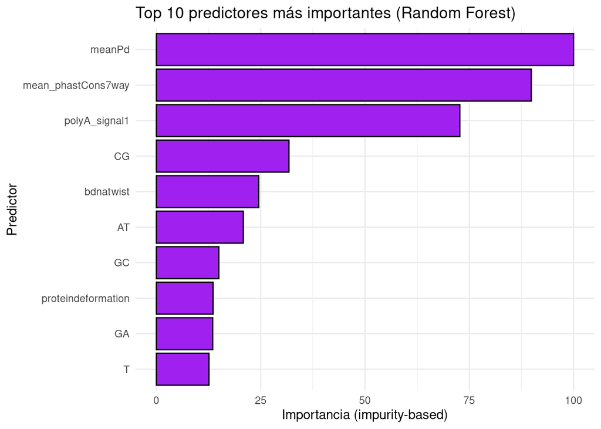

```r
# Gráfico con ggplot2
ggplot(importancia_top, aes(x = reorder(Variable, Overall), y = Overall)) +
  geom_bar(stat = "identity", fill = "purple", color = "black") +
  coord_flip() +
  labs(
    title = "Top 10 predictores más importantes (Random Forest)",
    x = "Predictor",
    y = "Importancia (impurity-based)"
  ) +
  theme_minimal()
```

El análisis de importancia de variables revela que los predictores más relevantes para la clasificación de las regiones genómicas son `meanPd`, `mean_phastCons7way` y `polyA_signal1`, con valores de importancia notablemente superiores al resto. Esto sugiere que las propiedades biofísicas del ADN (`meanPd`), la conservación evolutiva (`mean_phastCons7way`) y la presencia del motivo de señal de poliadenilación (`polyA_signal1`) son especialmente discriminativas entre clases. Además, variables relacionadas con la estructura del ADN (`bdnatwist`, `proteindeformation`) y la composición de dinucleótidos (`CG`, `AT`, `GA`, `T`) también contribuyen significativamente. En conjunto, estos resultados apoyan la hipótesis de que tanto las características estructurales como las secuenciales del ADN juegan un papel clave en la diferenciación de los loci analizados.

## **4. Conclusiones**

A lo largo de este estudio se ha llevado a cabo un análisis exhaustivo para clasificar distintos tipos de regiones genómicas utilizando técnicas de aprendizaje automático. Mediante un preprocesamiento cuidadoso, se abordaron problemas comunes como el desbalance de clases y la multicolinealidad, lo que permitió entrenar modelos más robustos. El análisis exploratorio reveló patrones diferenciables en variables clave, mientras que el Análisis de Componentes Principales (PCA) facilitó la visualización de la separabilidad entre clases como `ICE`, `UTR` y `5-UTR`, aunque otras como `lncRNA`, `ncRNA` y `pseudoGene` presentaron un fuerte solapamiento. Ambos modelos evaluados, Random Forest y SVM radial, mostraron un rendimiento global elevado (Accuracy > 86%), siendo **Random Forest** finalmente seleccionado por ofrecer interpretabilidad de variables, un rendimiento competitivo y mayor robustez frente al desbalance. Las variables más relevantes (como `meanPd`, `mean_phastCons7way` y `polyA_signal1`) demostraron un alto poder discriminativo. Este análisis confirma que es posible construir clasificadores eficaces para predecir el tipo de región genómica, especialmente al integrar métodos estadísticos y computacionales en un flujo de trabajo reproducible.